# 4_scRNAseq

## Master Medical Biometry/Biostatistics, Introduction to Bioinformatics, Medizinische Fakultät Heidelberg

**The purpose of these exercises is to introduce you to the post-processing of single cell RNA-seq data, in this case identification of gene markers.**

> Provide answers to questions that are marked with ‘Q’.

## The Data

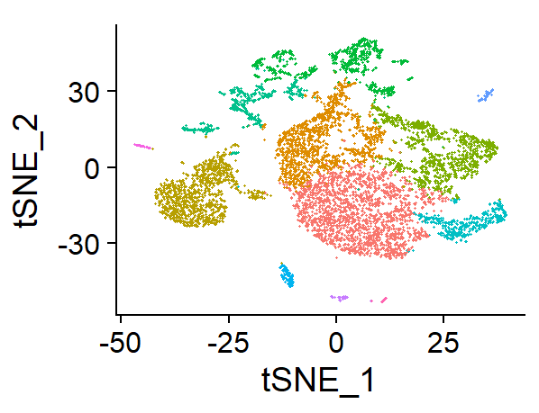

We will be using a dataset generated by [10X genomics](https://www.10xgenomics.com/solutions/single-cell/), a leading company in providing single cell chemistry, hardware and software. The [dataset](https://support.10xgenomics.com/single-cell-gene-expression/datasets/2.1.0/neuron_9k) includes 9k Brain Cells from cortex, hippocampus and subventricular zones of an E18 Mouse. Some statistics for this dataset can be found [here](http://cf.10xgenomics.com/samples/cell-exp/2.1.0/neuron_9k/neuron_9k_web_summary.html), and in summary:

```
9,128 cells detected
Sequenced on Illumina Hiseq4000 with approximately 42,000 reads per cell
```

The data was processed using [Cell Ranger](https://support.10xgenomics.com/single-cell-gene-expression/software/pipelines/latest/what-is-cell-ranger), which:

- generated the raw FastQ files
- filtered and aligned the reads to the reference genome
- counted barcodes and UMIs
- generated feature barcode matrices

Download the [filtered_gene_bc_matrices.zip](https://drive.google.com/file/d/1x3dHC7f2w3SQ1dKRWkgBuw_OLdPX_mPc/view?usp=sharing) folder unzip it.

## Loading packages

There are many software packages for analyzing single cell RNA data; [Monocle](http://cole-trapnell-lab.github.io/monocle-release/), [Scanpy](https://scanpy.readthedocs.io/en/stable/tutorials.html) and [Seurat](https://satijalab.org/seurat/) among others. For today’s practical we will use Seurat, one of the most common tools. Seurat takes a count matrix as input and uses several statistical methods to perform clustering and differential expression on the data.

Start `R` in your local computer.

Select your working directory (where you saved the `filtered_gene_bc_matrices` folder) by clicking:

```
Session -> Set Working Directory -> Choose directory
```

*This is a `copy/paste` tutorial so we can focus on the interpretation of the results; however it is important to understand what each line is doing, so if you have any questions, just raise your hand!*

Load the following libraries:

```r
library(Seurat)
library(dplyr)
library(DT)
```

And the count matrix:

```r
# Reading the barcodes, genes and matrix information
neuron.data <- Read10X(data.dir = "filtered_gene_bc_matrices/mm10")
str(neuron.data)
```

```
## Formal class 'dgCMatrix' [package "Matrix"] with 6 slots
##   ..@ i       : int [1:23647910] 8 33 62 68 95 114 118 130 188 193 ...
##   ..@ p       : int [1:9129] 0 1467 4594 5961 8556 12590 15014 18558 19840 22076 ...
##   ..@ Dim     : int [1:2] 27998 9128
##   ..@ Dimnames:List of 2
##   .. ..$ : chr [1:27998] "Xkr4" "Gm1992" "Gm37381" "Rp1" ...
##   .. ..$ : chr [1:9128] "AAACCTGAGACGCTTT-1" "AAACCTGAGATCTGCT-1" "AAACCTGAGGTCATCT-1" "AAACCTGCAAGAGTCG-1" ...
##   ..@ x       : num [1:23647910] 2 1 7 1 1 1 1 2 2 1 ...
##   ..@ factors : list()
```

> Q1. How many cells and genes are we working with?

**Click here for answer**

```
27998 genes
9128 cells
```

Now we create a `Seurat object` where counts and all metadata will be stored. While creating the object, we can start doing some filtering, for instance, we can remove genes that are lowly expressed (`min.cells`) and cells that have too little amount of genes (`min,.features`):

```r
# Creating the seurat object, you can use different thresholds for the
#  amount of cells and genes (features)
neuron <- CreateSeuratObject(counts = neuron.data,
                             project = "neuron",
                             min.cells = 3,
                             min.features = 200)
str(neuron)
```

```
## Formal class 'Seurat' [package "SeuratObject"] with 13 slots
##   ..@ assays      :List of 1
##   .. ..$ RNA:Formal class 'Assay5' [package "SeuratObject"] with 8 slots
##   .. .. .. ..@ layers    :List of 1
##   .. .. .. .. ..$ counts:Formal class 'dgCMatrix' [package "Matrix"] with 6 slots
##   .. .. .. .. .. .. ..@ i       : int [1:23638195] 4 23 44 48 63 73 77 83 118 122 ...
##   .. .. .. .. .. .. ..@ p       : int [1:9084] 0 1467 4594 5961 8555 12589 15013 18556 19838 22074 ...
##   .. .. .. .. .. .. ..@ Dim     : int [1:2] 17311 9083
##   .. .. .. .. .. .. ..@ Dimnames:List of 2
##   .. .. .. .. .. .. .. ..$ : NULL
##   .. .. .. .. .. .. .. ..$ : NULL
##   .. .. .. .. .. .. ..@ x       : num [1:23638195] 2 1 7 1 1 1 1 2 2 1 ...
##   .. .. .. .. .. .. ..@ factors : list()
##   .. .. .. ..@ cells     :Formal class 'LogMap' [package "SeuratObject"] with 1 slot
##   .. .. .. .. .. ..@ .Data: logi [1:9083, 1] TRUE TRUE TRUE TRUE TRUE TRUE ...
##   .. .. .. .. .. .. ..- attr(*, "dimnames")=List of 2
##   .. .. .. .. .. .. .. ..$ : chr [1:9083] "AAACCTGAGACGCTTT-1" "AAACCTGAGATCTGCT-1" "AAACCTGAGGTCATCT-1" "AAACCTGCAAGAGTCG-1" ...
##   .. .. .. .. .. .. .. ..$ : chr "counts"
##   .. .. .. .. .. ..$ dim     : int [1:2] 9083 1
##   .. .. .. .. .. ..$ dimnames:List of 2
##   .. .. .. .. .. .. ..$ : chr [1:9083] "AAACCTGAGACGCTTT-1" "AAACCTGAGATCTGCT-1" "AAACCTGAGGTCATCT-1" "AAACCTGCAAGAGTCG-1" ...
##   .. .. .. .. .. .. ..$ : chr "counts"
##   .. .. .. ..@ features  :Formal class 'LogMap' [package "SeuratObject"] with 1 slot
##   .. .. .. .. .. ..@ .Data: logi [1:17311, 1] TRUE TRUE TRUE TRUE TRUE TRUE ...
##   .. .. .. .. .. .. ..- attr(*, "dimnames")=List of 2
##   .. .. .. .. .. .. .. ..$ : chr [1:17311] "Xkr4" "Rp1" "Sox17" "Mrpl15" ...
##   .. .. .. .. .. .. .. ..$ : chr "counts"
##   .. .. .. .. .. ..$ dim     : int [1:2] 17311 1
##   .. .. .. .. .. ..$ dimnames:List of 2
##   .. .. .. .. .. .. ..$ : chr [1:17311] "Xkr4" "Rp1" "Sox17" "Mrpl15" ...
##   .. .. .. .. .. .. ..$ : chr "counts"
##   .. .. .. ..@ default   : int 1
##   .. .. .. ..@ assay.orig: chr(0)
##   .. .. .. ..@ meta.data :'data.frame':  17311 obs. of  0 variables
##   .. .. .. ..@ misc      :List of 1
##   .. .. .. .. ..$ calcN: logi TRUE
##   .. .. .. ..@ key       : chr "rna_"
##   ..@ meta.data   :'data.frame': 9083 obs. of  3 variables:
##   .. ..$ orig.ident  : Factor w/ 1 level "neuron": 1 1 1 1 1 1 1 1 1 1 ...
##   .. ..$ nCount_RNA  : num [1:9083] 3171 8936 2853 7574 18053 ...
##   .. ..$ nFeature_RNA: int [1:9083] 1467 3127 1367 2594 4034 2424 3543 1282 2236 1313 ...
##   ..@ active.assay: chr "RNA"
##   ..@ active.ident: Factor w/ 1 level "neuron": 1 1 1 1 1 1 1 1 1 1 ...
##   .. ..- attr(*, "names")= chr [1:9083] "AAACCTGAGACGCTTT-1" "AAACCTGAGATCTGCT-1" "AAACCTGAGGTCATCT-1" "AAACCTGCAAGAGTCG-1" ...
##   ..@ graphs      : list()
##   ..@ neighbors   : list()
##   ..@ reductions  : list()
##   ..@ images      : list()
##   ..@ project.name: chr "neuron"
##   ..@ misc        : list()
##   ..@ version     :Classes 'package_version', 'numeric_version'  hidden list of 1
##   .. ..$ : int [1:3] 5 0 2
##   ..@ commands    : list()
##   ..@ tools       : list()
```

> Q2. How many cells and genes do we have now? Were some of them removed?

**Click here for answer**

```
17311 genes
9083 cells out of 9128 original cells

27998 genes
9128 cells

yes aroung 0.5% were removed
```

## Quality control and filtering

Here we will remove cells and genes that can create biases due to cell duplicates, cell lysis and cells with very few reads in total.

First, let’s calculate the percentage of mitochondrial gene expression for every cell, this will give us an idea of the quality of the cells, for example, high proportions of mitochondrial genes indicate the loss of cytoplasmic RNA (e.g., perforated cells).

```r
# Calculating mitochondrial content, in this case mitochondrial
# genes are annotated as "mt-Cytb"
neuron[["percent.mt"]] <- PercentageFeatureSet(neuron, pattern = "^mt-")
head(neuron[[]])
```

```
##                    orig.ident nCount_RNA nFeature_RNA percent.mt
## AAACCTGAGACGCTTT-1     neuron       3171         1467   6.559445
## AAACCTGAGATCTGCT-1     neuron       8936         3127   3.290063
## AAACCTGAGGTCATCT-1     neuron       2853         1367   2.979320
## AAACCTGCAAGAGTCG-1     neuron       7574         2594   4.264589
## AAACCTGCACACATGT-1     neuron      18053         4034   3.639284
## AAACCTGCACATGGGA-1     neuron       5885         2424   3.704333
```

```r
summary(neuron[["percent.mt"]])
```

```
##    percent.mt
##  Min.   : 0.05088
##  1st Qu.: 2.50411
##  Median : 3.06564
##  Mean   : 3.34252
##  3rd Qu.: 3.76681
##  Max.   :27.13699
```

> Q3. What is the maximum percentage of mitochondrial content?

**Click here for answer**

```
27.13699  %
```

In the `summary(neuron[["percent.mt"]])` code above, replace `percent.mt` with `nFeature_RNA` (this indicates the number of genes quantified per cell) and rerun that line.

```r
summary(neuron[["nFeature_RNA"]])
```

```
##   nFeature_RNA
##  Min.   : 202
##  1st Qu.:1991
##  Median :2513
##  Mean   :2602
##  3rd Qu.:3063
##  Max.   :7825
```

> Q4.How many more genes are expressed between the cell with less genes and the cell with most genes?

**Click here for answer**

[output not shown]

Now let’s visualize these metrics, using different types of plots:

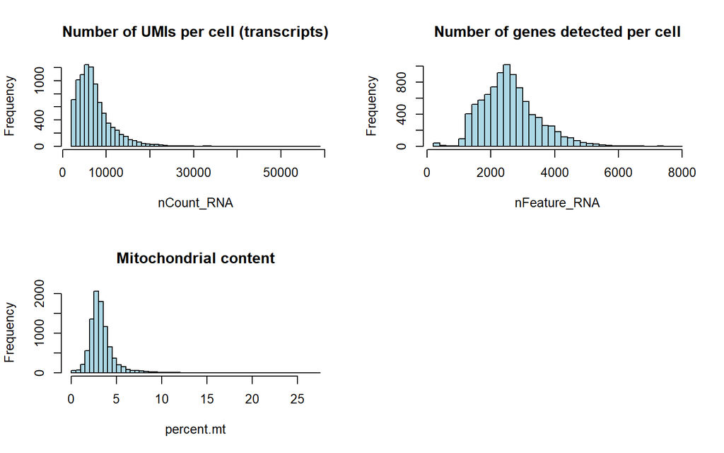

```r
# Histograms
mycolor="lightblue"
par(mfrow = c(2,2))
hist(neuron[["nCount_RNA"]][,1],
     breaks = 50,
     col    = mycolor,
     main   = "Number of UMIs per cell (transcripts)",
     xlab   = "nCount_RNA")
hist(neuron[["nFeature_RNA"]][,1],
     breaks = 50,
     col    = mycolor,
     main   = "Number of genes detected per cell",
     xlab   = "nFeature_RNA")
hist(neuron[["percent.mt"]][,1],
     breaks = 50,
     col    = mycolor,
     main   = "Mitochondrial content",
     xlab   = "percent.mt")
par(mfrow = c(1,1))
```

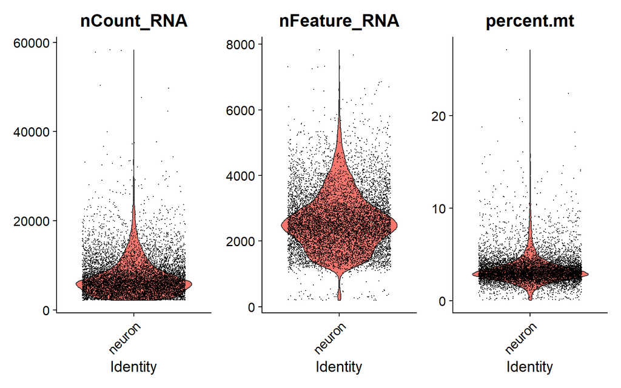

```r
# Violin plot
VlnPlot(neuron,
        features = c("nCount_RNA", "nFeature_RNA", "percent.mt"),
        ncol = 3)
```

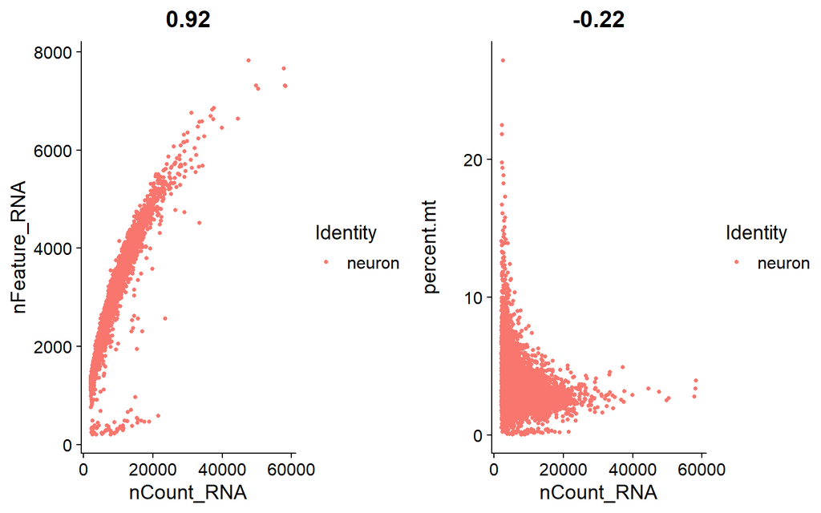

```r
# Scatter plots
percent.mt <- FeatureScatter(neuron,
                             feature1 = "nCount_RNA",
                             feature2 = "percent.mt")
nFeature_RNA <- FeatureScatter(neuron,
                               feature1 = "nCount_RNA",
                               feature2 = "nFeature_RNA")
CombinePlots(plots = list(nFeature_RNA, percent.mt))
```

Using the plots, try to decide on some thresholds to filter our data:

- From the `nFeature plots`, set up:
  - Max number of genes in a cell (MAX_F) = _____
  - Min number of genes in a cell (MIN_F) = _____
- From the `percent.mt plots`, set up:
  - Max mitochondrial expression (MAX_MT) = _____

Once you have decided, use these values in the following code to filter the bad quality data:

```r
neuron <- subset(neuron,
          subset = nFeature_RNA > MIN_F & nFeature_RNA < MAX_F & percent.mt < MAX_MT)
str(neuron)
```

```r
neuron <- subset(neuron,
          subset = nFeature_RNA > 500 & nFeature_RNA < 6000 & percent.mt < 20)
str(neuron)
```

```
## Formal class 'Seurat' [package "SeuratObject"] with 13 slots
##   ..@ assays      :List of 1
##   .. ..$ RNA:Formal class 'Assay5' [package "SeuratObject"] with 8 slots
##   .. .. .. ..@ layers    :List of 1
##   .. .. .. .. ..$ counts:Formal class 'dgCMatrix' [package "Matrix"] with 6 slots
##   .. .. .. .. .. .. ..@ i       : int [1:23446119] 4 23 44 48 63 73 77 83 118 122 ...
##   .. .. .. .. .. .. ..@ p       : int [1:9007] 0 1467 4594 5961 8555 12589 15013 18556 19838 22074 ...
##   .. .. .. .. .. .. ..@ Dim     : int [1:2] 17311 9006
##   .. .. .. .. .. .. ..@ Dimnames:List of 2
##   .. .. .. .. .. .. .. ..$ : NULL
##   .. .. .. .. .. .. .. ..$ : NULL
##   .. .. .. .. .. .. ..@ x       : num [1:23446119] 2 1 7 1 1 1 1 2 2 1 ...
##   .. .. .. .. .. .. ..@ factors : list()
##   .. .. .. ..@ cells     :Formal class 'LogMap' [package "SeuratObject"] with 1 slot
##   .. .. .. .. .. ..@ .Data: logi [1:9006, 1] TRUE TRUE TRUE TRUE TRUE TRUE ...
##   .. .. .. .. .. .. ..- attr(*, "dimnames")=List of 2
##   .. .. .. .. .. .. .. ..$ : chr [1:9006] "AAACCTGAGACGCTTT-1" "AAACCTGAGATCTGCT-1" "AAACCTGAGGTCATCT-1" "AAACCTGCAAGAGTCG-1" ...
##   .. .. .. .. .. .. .. ..$ : chr "counts"
##   .. .. .. .. .. ..$ dim     : int [1:2] 9006 1
##   .. .. .. .. .. ..$ dimnames:List of 2
##   .. .. .. .. .. .. ..$ : chr [1:9006] "AAACCTGAGACGCTTT-1" "AAACCTGAGATCTGCT-1" "AAACCTGAGGTCATCT-1" "AAACCTGCAAGAGTCG-1" ...
##   .. .. .. .. .. .. ..$ : chr "counts"
##   .. .. .. ..@ features  :Formal class 'LogMap' [package "SeuratObject"] with 1 slot
##   .. .. .. .. .. ..@ .Data: logi [1:17311, 1] TRUE TRUE TRUE TRUE TRUE TRUE ...
##   .. .. .. .. .. .. ..- attr(*, "dimnames")=List of 2
##   .. .. .. .. .. .. .. ..$ : chr [1:17311] "Xkr4" "Rp1" "Sox17" "Mrpl15" ...
##   .. .. .. .. .. .. .. ..$ : chr "counts"
##   .. .. .. .. .. ..$ dim     : int [1:2] 17311 1
##   .. .. .. .. .. ..$ dimnames:List of 2
##   .. .. .. .. .. .. ..$ : chr [1:17311] "Xkr4" "Rp1" "Sox17" "Mrpl15" ...
##   .. .. .. .. .. .. ..$ : chr "counts"
##   .. .. .. ..@ default   : int 1
##   .. .. .. ..@ assay.orig: chr(0)
##   .. .. .. ..@ meta.data :'data.frame':  17311 obs. of  0 variables
##   .. .. .. ..@ misc      :List of 1
##   .. .. .. .. ..$ calcN: logi TRUE
##   .. .. .. ..@ key       : chr "rna_"
##   ..@ meta.data   :'data.frame': 9006 obs. of  4 variables:
##   .. ..$ orig.ident  : Factor w/ 1 level "neuron": 1 1 1 1 1 1 1 1 1 1 ...
##   .. ..$ nCount_RNA  : num [1:9006] 3171 8936 2853 7574 18053 ...
##   .. ..$ nFeature_RNA: int [1:9006] 1467 3127 1367 2594 4034 2424 3543 1282 2236 1313 ...
##   .. ..$ percent.mt  : num [1:9006] 6.56 3.29 2.98 4.26 3.64 ...
##   ..@ active.assay: chr "RNA"
##   ..@ active.ident: Factor w/ 1 level "neuron": 1 1 1 1 1 1 1 1 1 1 ...
##   .. ..- attr(*, "names")= chr [1:9006] "AAACCTGAGACGCTTT-1" "AAACCTGAGATCTGCT-1" "AAACCTGAGGTCATCT-1" "AAACCTGCAAGAGTCG-1" ...
##   ..@ graphs      : list()
##   ..@ neighbors   : list()
##   ..@ reductions  : list()
##   ..@ images      : list()
##   ..@ project.name: chr "neuron"
##   ..@ misc        : list()
##   ..@ version     :Classes 'package_version', 'numeric_version'  hidden list of 1
##   .. ..$ : int [1:3] 5 0 2
##   ..@ commands    : list()
##   ..@ tools       : list()
```

> Q5. How many cells and genes were filtered out?

**Click here for answer**

[output not shown]

## Normalization, data scaling and dimensional reduction

```r
# Data normalization
neuron <- NormalizeData(neuron,
                        normalization.method = "LogNormalize",
                        scale.factor = 10000)
```

```
## Normalizing layer: counts
```

```r
#str(neuron)

# Identifying the most varialb genes
neuron <- FindVariableFeatures(neuron,
                               selection.method = "vst",
                               nfeatures = 2000)
```

```
## Finding variable features for layer counts
```

```r
#str(neuron)

# Selecting the top 10 variable genes
top10 <- head(VariableFeatures(neuron), 10)
top10
```

```
##  [1] "Hbb-bs" "Hba-a1" "Hba-a2" "Cldn5"  "Igfbp7" "Rgs5"   "Nts"    "Snhg11"
##  [9] "C1qb"   "Hbb-bt"
```

Now let’s visualize all the genes, indicating which are the most variable ones and labeling the 10 genes that we selected:

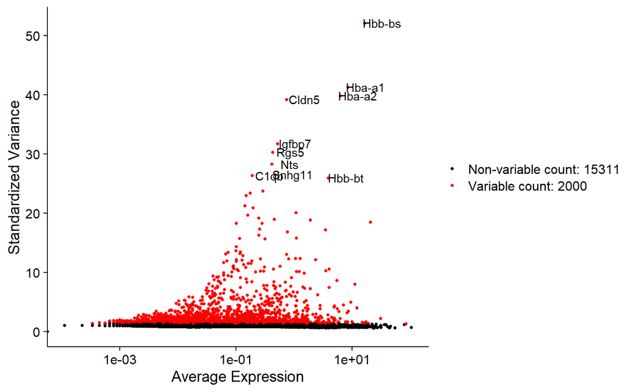

```r
variableGenes <- VariableFeaturePlot(neuron)
LabelPoints(plot = variableGenes, points = top10)
```

Next we will scale the data and run a PCA:

```r
# Data scaling
neuron <- ScaleData(neuron)
#str(neuron)

# Running PCA
neuron <- RunPCA(neuron)
```

```
## PC_ 1
## Positive:  Tubb3, Tuba1a, Stmn3, Sox11, Crmp1, Stmn2, Nnat, Igfbpl1, Mapt, Stmn4
##     Neurod6, Neurod2, Gria2, Dpysl3, Map1b, Uchl1, Bcl11a, Ly6h, Thra, Mpped1
##     Bhlhe22, Ttc28, Rbfox1, Cntn2, Cnih2, Olfm1, Syt4, Gpm6a, Elavl2, Nrp1
## Negative:  Sparc, Mfge8, Vim, Zfp36l1, Rhoc, Atp1a2, Gng5, Hes1, Phgdh, Dbi
##     Tagln2, Serpinh1, Pon2, Apoe, Slc9a3r1, Ddah1, Hmgb2, Qk, Mt1, Fabp7
##     Slco1c1, Anxa2, Slc1a3, Id3, Mt3, Aldoc, Msn, Gng11, Gpx8, Gnai2
## PC_ 2
## Positive:  Hmgb2, Pbk, Phgdh, Cdca3, Ccna2, Birc5, Tpx2, Cdca8, Fabp7, Top2a
##     Ube2c, Ccnb1, 2810417H13Rik, H2afz, Cenpf, Lockd, Dbi, Cks2, Spc24, Spc25
##     Prc1, Cdk1, Mki67, Nusap1, Slc1a3, Cdkn2c, Fam64a, Cenpa, Tacc3, Gas1
## Negative:  Igfbp7, Esam, Eng, Gng11, Ecscr, BC028528, Col4a2, Cldn5, Foxq1, Emcn
##     Col4a1, Cd34, Flt1, Eva1b, Slc40a1, Epas1, Apod, Kdr, Sepp1, Vwa1
##     Slc22a8, Foxf2, Adgrf5, Itm2a, Lama4, Grap, Egfl7, Tgfb1, Klf2, Rhoj
## PC_ 3
## Positive:  Birc5, Ube2c, Ccna2, Spc25, Top2a, Nusap1, Tpx2, Cdca8, Cdca3, Pbk
##     2810417H13Rik, Ccnb1, Mki67, Cks2, Cdk1, Prc1, Aurkb, Hmmr, Spc24, Cdc20
##     Kif2c, Ckap2l, Kif22, Fam64a, Kif11, Cdca2, Melk, Aurka, Mis18bp1, Plk1
## Negative:  Aldoc, Clu, Mt3, Ttyh1, Tnc, Mlc1, Pdpn, Apoe, Ndrg2, Cspg5
##     Ccdc80, Mt1, Hes5, Slc9a3r1, Id4, Slc1a3, Atp1a2, Aldh1l1, Fgfbp3, Plpp3
##     Mt2, Naaa, Phgdh, Ddah1, Fabp7, Pla2g7, Pea15a, Emp2, Gfap, Vcam1
## PC_ 4
## Positive:  Igfbp7, Gng11, Col4a2, Esam, Tuba1a, Cldn5, Itm2a, Col4a1, Emcn, Foxq1
##     Nid1, Flt1, Apod, Vwa1, Rhoj, Slc22a8, Tsc22d1, Dlc1, Ramp2, Epas1
##     Adgrf5, Kdr, Lama4, Sept4, Foxf2, Bgn, Ctla2a, Ifitm3, Arhgap29, Crip2
## Negative:  Tyrobp, C1qb, C1qc, C1qa, Fcrls, Fcer1g, Ctss, Ly86, Trem2, Aif1
##     Crybb1, Hexb, Csf1r, Fcgr3, P2ry12, Ccl3, Cx3cr1, Adgre1, Ltc4s, Laptm5
##     Pld4, Spi1, Rac2, Gpr34, Cd53, Ccl4, Olfml3, Evi2a, Hpgds, Bcl2a1b
## PC_ 5
## Positive:  Ndufa4l2, Vtn, Kcnj8, Rgs5, Higd1b, Igf2, Abcc9, Rgs4, Dlk1, Cd248
##     Pdgfrb, Vstm4, Cox4i2, Ifitm1, Foxs1, Bgn, Heyl, Ednra, Pdlim2, Mylk
##     Pde8b, S1pr3, Gja4, Tbxa2r, Il34, Nupr1, Col1a2, Myl9, Itih5, Eva1b
## Negative:  Cldn5, Cd34, Vwa1, Ctla2a, Pglyrp1, AU021092, Slc38a5, Pecam1, Cdh5, Slc39a8
##     Slc40a1, Lsr, Flt1, Cd93, Tmem252, Htra3, Ly6c1, Adgrl4, Kdr, Aplnr
##     Slc2a1, Sox17, Icam2, Mfsd2a, Fam101b, Cav1, Egfl7, Anxa3, Gimap1, Tie1
```

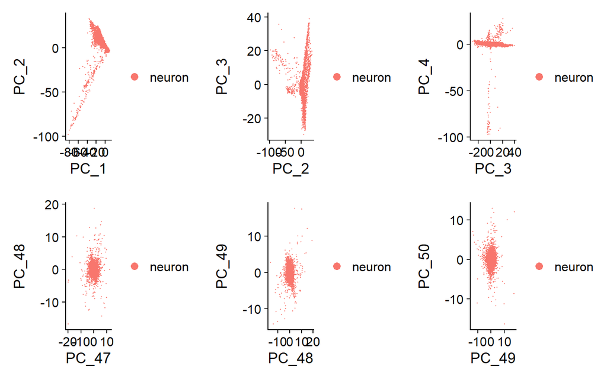

```r
#str(neuron)

# ploting different PCs: top 3 and bottom 3
p1<-DimPlot(neuron, dims = c(1,2), reduction = "pca")
p2<-DimPlot(neuron, dims = c(2,3), reduction = "pca")
p3<-DimPlot(neuron, dims = c(3,4), reduction = "pca")
p4<-DimPlot(neuron, dims = c(47,48), reduction = "pca")
p5<-DimPlot(neuron, dims = c(48,49), reduction = "pca")
p6<-DimPlot(neuron, dims = c(49,50), reduction = "pca")
CombinePlots(plots = list(p1,p2,p3,p4,p5,p6))
```

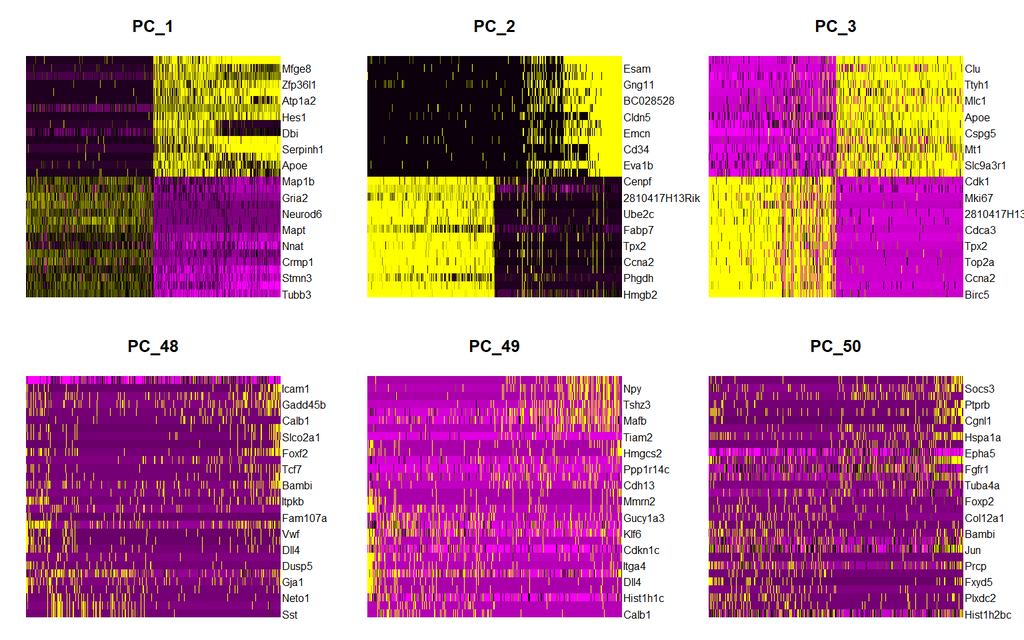

```r
# plotting different PCs as heatmaps, top 3 and bottom 3
DimHeatmap(neuron, dims = c(1:3,48:50), cells = 500)
```

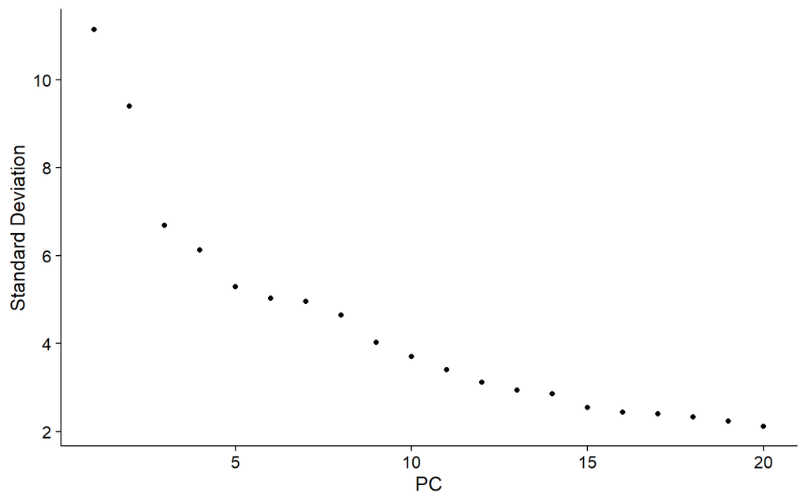

```r
# Plotting PCs in function of the std deviation
ElbowPlot(neuron)
```

Looking at the `ElbowPlot`, let’s decide on how many PCs we will include to perform the clustering. Remember that using too many PCs, might find rare subtypes of cells but adds noise to the data; and using too few, we won’t get enough information. This is a trial an error decision, so we never get it correct the first time!

- Select a PC where the STDDEV plateaus (PLATEAU): _____

Once you have decided, use this value in the following code to perform the clustering and its visualization:

```r
PLATEAU=15
# First we find the neighbors
neuron <- FindNeighbors(neuron, dims = 1:PLATEAU)
# str(neuron)

# Then we find the clusters (you can change the resolution, where lower values will give you more clusters)
neuron <- FindClusters(neuron, resolution = 0.2)
```

```
## Modularity Optimizer version 1.3.0 by Ludo Waltman and Nees Jan van Eck
##
## Number of nodes: 9006
## Number of edges: 314405
##
## Running Louvain algorithm...
## Maximum modularity in 10 random starts: 0.9399
## Number of communities: 11
## Elapsed time: 0 seconds
```

```r
#str(neuron)

# We run the non-linear dimensional reduction (UMAP/tSNE)
neuron <- RunUMAP(neuron, dims = 1:PLATEAU)
```

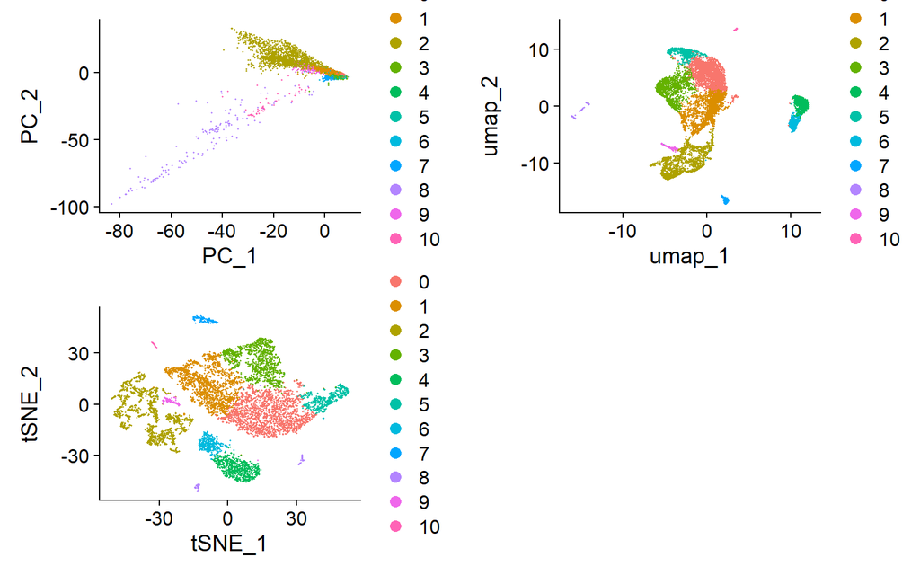

```r
neuron <- RunTSNE(neuron, dims = 1:PLATEAU)
#str(neuron)

# And finally we visualize the clusters
pca <- DimPlot(neuron, reduction = "pca")
umap <- DimPlot(neuron, reduction = "umap")
tsne <- DimPlot(neuron, reduction = "tsne")
CombinePlots(plots = list(pca,umap,tsne))
```

> Q6. What is your favorite visualization?

## Differential expression

In this part of the analysis, we will find genes that helps us to differentiate between the clusters, we call them `marker genes`. You can either compare one cluster to another or one cluster against all other clusters. Here let’s focus on one vs all. Since the following command takes more than 20 mins to complete, download the resulting object from [here](https://github.com/marceladavila/Intro2Bioinformatics/blob/master/neuron_markers.rds) and load it with the following code:

```r
# loop of comparisons: 1 vs all, 2 vs all, etc
# neuron.markers <- FindAllMarkers(neuron,
#                                  only.pos = TRUE,
#                                  min.pct = 0.25,
#                                  logfc.threshold = 0.0001)

# loading the results object from the FindAllMarkers function
neuron.markers <- readRDS(file = "neuron_markers.rds")
head(neuron.markers)
```

```
##         p_val avg_logFC pct.1 pct.2 p_val_adj cluster    gene
## Gpm6a       0 0.9592718 0.954 0.737         0       0   Gpm6a
## Syt4        0 0.9460474 0.784 0.290         0       0    Syt4
## Satb2       0 0.9402206 0.638 0.109         0       0   Satb2
## Gria2       0 0.9349454 0.969 0.699         0       0   Gria2
## Dab1        0 0.9075174 0.718 0.240         0       0    Dab1
## Bhlhe22     0 0.8567723 0.816 0.348         0       0 Bhlhe22
```

```r
table(neuron.markers$cluster)
```

```
##
##    0    1    2    3    4    5    6    7    8    9   10
## 1579 1211 1299 2603 2239 2088 1704 2620 1208  789   29
```

> Q7. Which is the cluster with the least amount of marker genes?

**Click here for answer**

```
cluster 10 (under these thresholds) is the cluster with only 29 genes
```

Let’s select the first 5 markers for each cluster and visualize them. Replace `REDUCTION` with `"pca"`, `"tsne"` or `"umap"`, depending on which visualization you want to display:

```r
# Identifying markers
top5 <- neuron.markers %>% group_by(cluster) %>% top_n(n = 5, wt = avg_logFC)
head(top5)
datatable(top5)

# Visualization
DoHeatmap(neuron, top5$gene)

VlnPlot(neuron, top5$gene[seq(1,60,by=5)])

DotPlot(neuron, features = top5$gene[seq(1,60,by=5)])

FeaturePlot(neuron, features = top5$gene[seq(1,60,by=5)], reduction = REDUCTION)
```

```r
# Identifying markers
top5 <- neuron.markers %>% group_by(cluster) %>% top_n(n = 5, wt = avg_logFC)
head(top5)
```

```
## # A tibble: 6 × 7
## # Groups:   cluster [2]
##   p_val avg_logFC pct.1 pct.2 p_val_adj cluster gene
##   <dbl>     <dbl> <dbl> <dbl>     <dbl> <fct>   <chr>
## 1     0     0.959 0.954 0.737         0 0       Gpm6a
## 2     0     0.946 0.784 0.29          0 0       Syt4
## 3     0     0.940 0.638 0.109         0 0       Satb2
## 4     0     0.935 0.969 0.699         0 0       Gria2
## 5     0     0.908 0.718 0.24          0 0       Dab1
## 6     0     1.09  0.494 0.103         0 1       Eomes
```

```r
datatable(top5)
```

|  | p_val | avg_logFC | pct.1 | pct.2 | p_val_adj | cluster | gene |
| --- | --- | --- | --- | --- | --- | --- | --- |
| 1 | 0 | 0.9592717948928331 | 0.954 | 0.737 | 0 | 0 | Gpm6a |
| 2 | 0 | 0.9460473784904736 | 0.784 | 0.29 | 0 | 0 | Syt4 |
| 3 | 0 | 0.94022064197955 | 0.638 | 0.109 | 0 | 0 | Satb2 |
| 4 | 0 | 0.9349453555832785 | 0.969 | 0.699 | 0 | 0 | Gria2 |
| 5 | 0 | 0.9075174496093432 | 0.718 | 0.24 | 0 | 0 | Dab1 |
| 6 | 0 | 1.089231431348105 | 0.494 | 0.103 | 0 | 1 | Eomes |
| 7 | 0 | 1.072436657860426 | 0.686 | 0.246 | 0 | 1 | Pcp4 |
| 8 | 0 | 0.9936079296860685 | 0.666 | 0.17 | 0 | 1 | Sstr2 |
| 9 | 0 | 0.8809084444816362 | 1 | 0.827 | 0 | 1 | Igfbpl1 |
| 10 | 6.219872651511277e-281 | 0.9228623640437285 | 0.515 | 0.16 | 1.076722154703117e-276 | 1 | Mfap4 |

[output cut: 45 more lines]

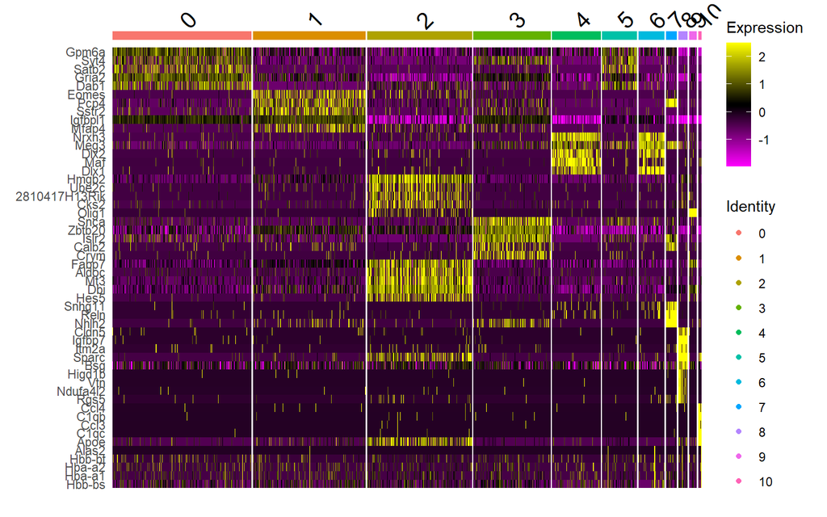

```r
# Visualization
DoHeatmap(neuron, top5$gene)
```

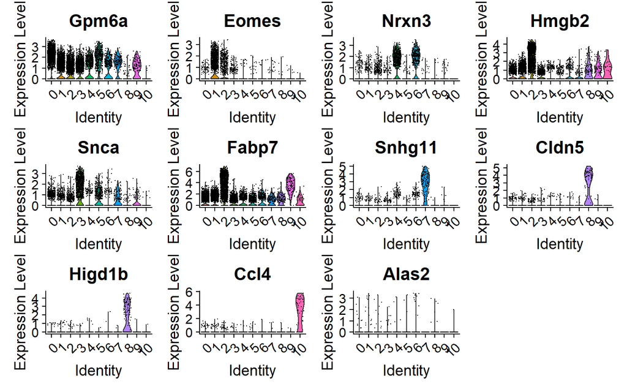

```r
VlnPlot(neuron, top5$gene[seq(1,60,by=5)])
```

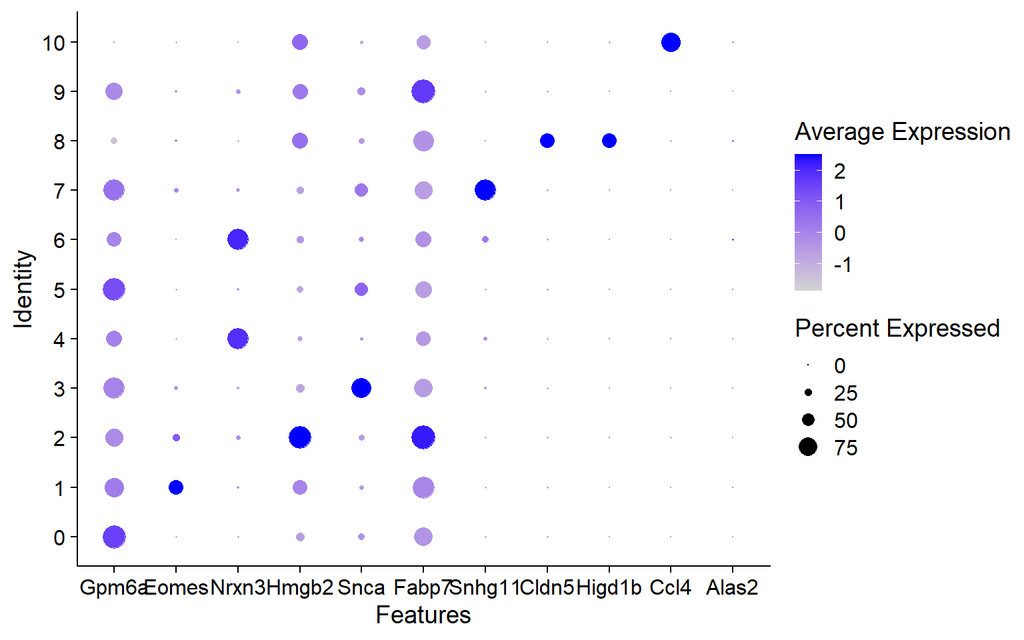

```r
DotPlot(neuron, features = top5$gene[seq(1,60,by=5)])
```

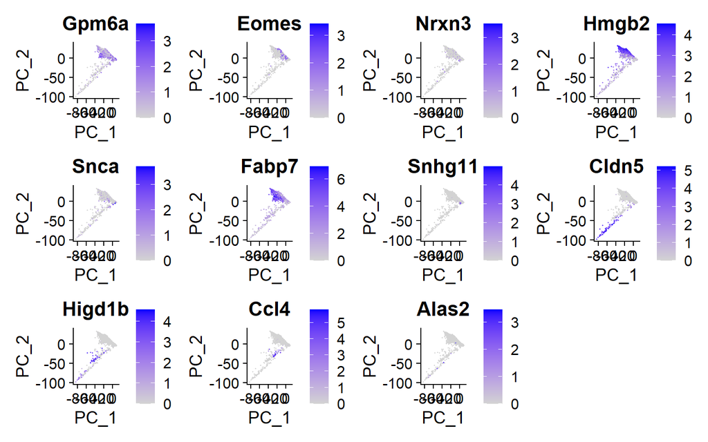

```r
FeaturePlot(neuron, features = top5$gene[seq(1,60,by=5)], reduction = "pca")
```

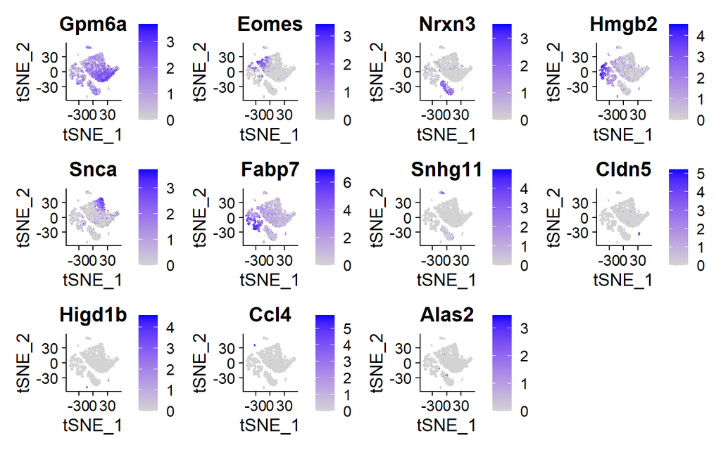

```r
FeaturePlot(neuron, features = top5$gene[seq(1,60,by=5)], reduction = "tsne")
```

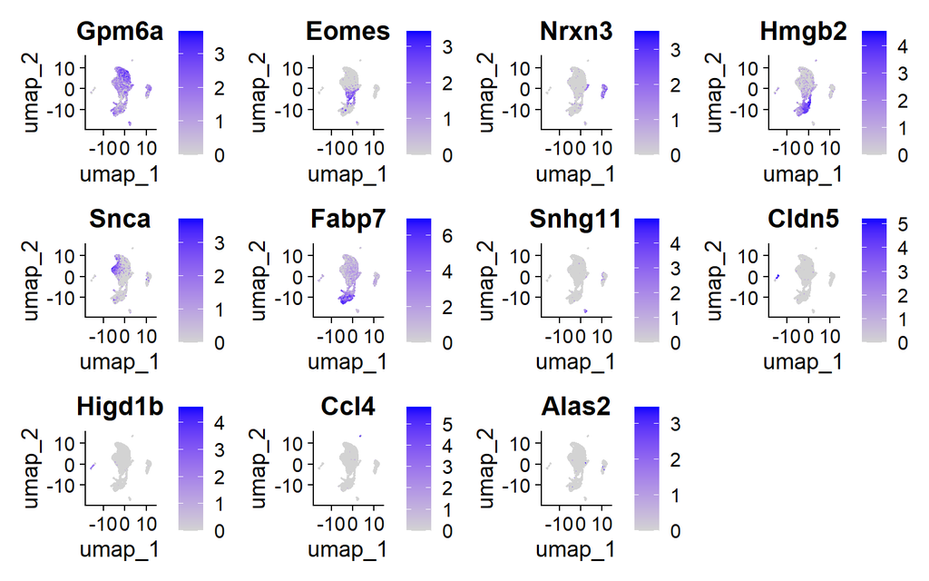

```r
FeaturePlot(neuron, features = top5$gene[seq(1,60,by=5)], reduction = "umap")
```

>Q9. Do the selected markers differentiate between the clusters?

**Click here for answer**

```
yes
```

### Well done! Now you have a general understanding on analyzing scRNseq data

### [Previous: RNAseq](https://github.com/marceladavila/Intro2Bioinformatics/wiki/3_RNAseq)

### [Home: Intro2Bioinformatics](https://github.com/marceladavila/Intro2Bioinformatics/wiki)

Based on: https://github.com/bcfgothenburg/HT19/wiki/R-scRNAseq, 2019